# Inside Context Memory

> This notebook focuses on context memory inside the rooms.

# 1 Overview of the data

The rooms were separated into *Familiar* and *Novel* groups. Participants explored the *Familiar* group at the beginning of the experiment. In the encoding task, they visisted both *Familiar* and *Novel* groups. Their context memory (i.e., in which room they saw the item) was tested in the memory test the next day of the encoding task. **Novelty benefits** on the context memory are examined by comparing the memory performance between the *Familiar* and *Novel* groups.

Participants were also asked to rate how curious they felt about the room. The higher the rating is means they felt more curious about the room. Context memory as a function of curiosity rating was also examined for **curiosity benefits**.

Questionnaires on personal traits regarding curiosity were also administered to participants before the encoding task (i.e., PC and EC). Scores on these questionnaires might be able to predict the context memory or its relationship with curiosity rating.

In the encoding task, there were 6 objects in each room. It is possbile that the context memory for the object to some extent depends on the order in which the object was seen. For example, it may be easier to remember where the first and last objects were seen as compared to those in the middle.

# 2 Individual performance

## 2.1 An overview of individual context memory performance as a function of room.

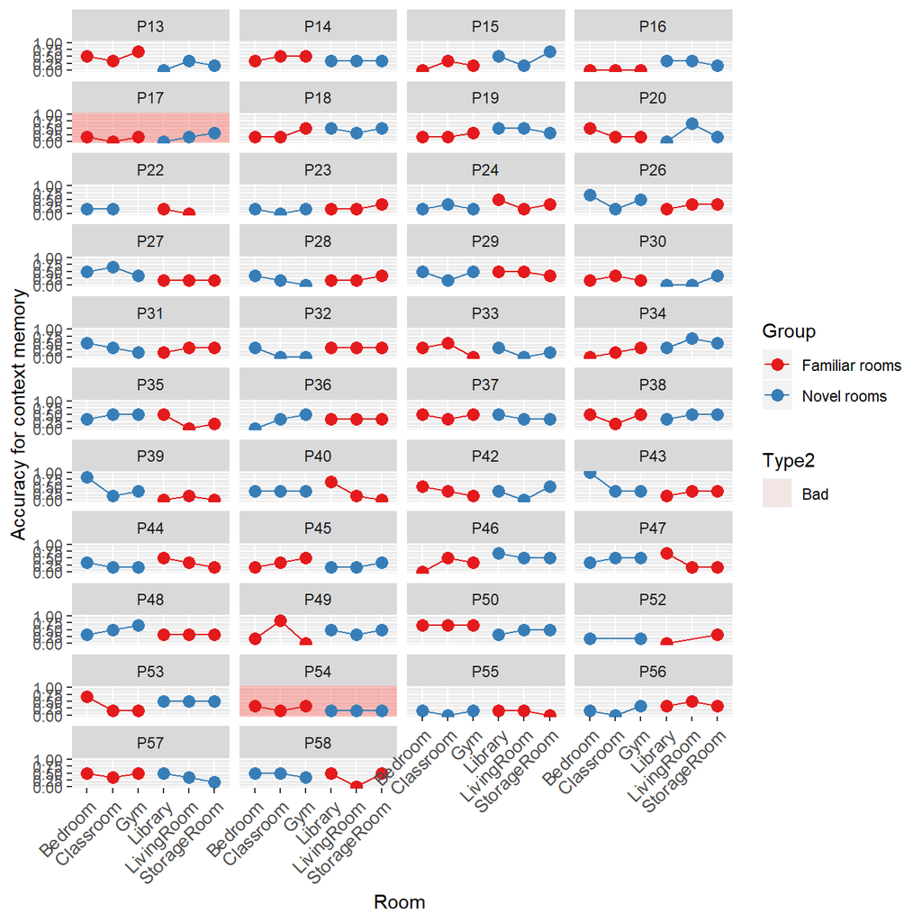

Figure1. Mean accuracy for context memory respectively for each room and each individual participant.

## 2.2 For correctly labelled distractor items

## 2.3 For correctly recalled items

[figure not shown]

# 3 Novelty Benefits

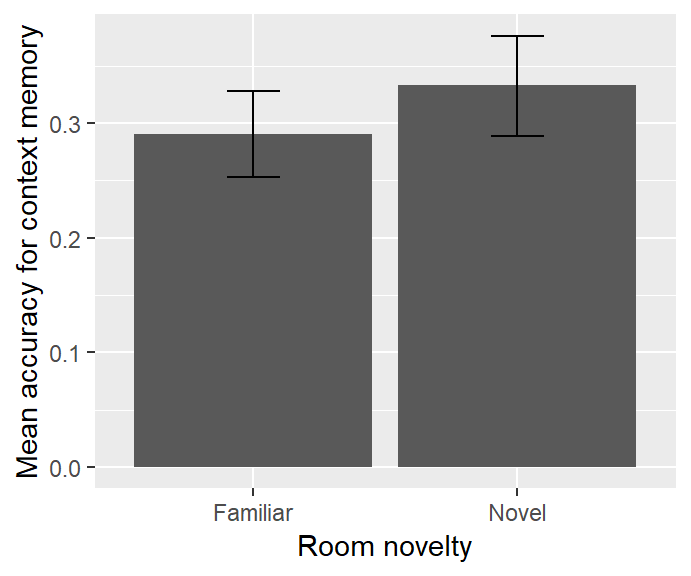

Figure4. Mean accuracy for context memory respectively for Familiar and Novel rooms.

As we predicted, the mean accuracy of context memory is higher in the *novel* rooms than in the *familiar* rooms.

```
##
##  Paired t-test
##
## data:  MeanContextAccuracy by Group
## t = -1.4984, df = 39, p-value = 0.1421
## alternative hypothesis: true difference in means is not equal to 0
## 95 percent confidence interval:
##  -0.09954610  0.01482388
## sample estimates:
## mean of the differences
##             -0.04236111
```

## 3.1 Context memory as a function of item order

### 3.1.1 Visualise the data

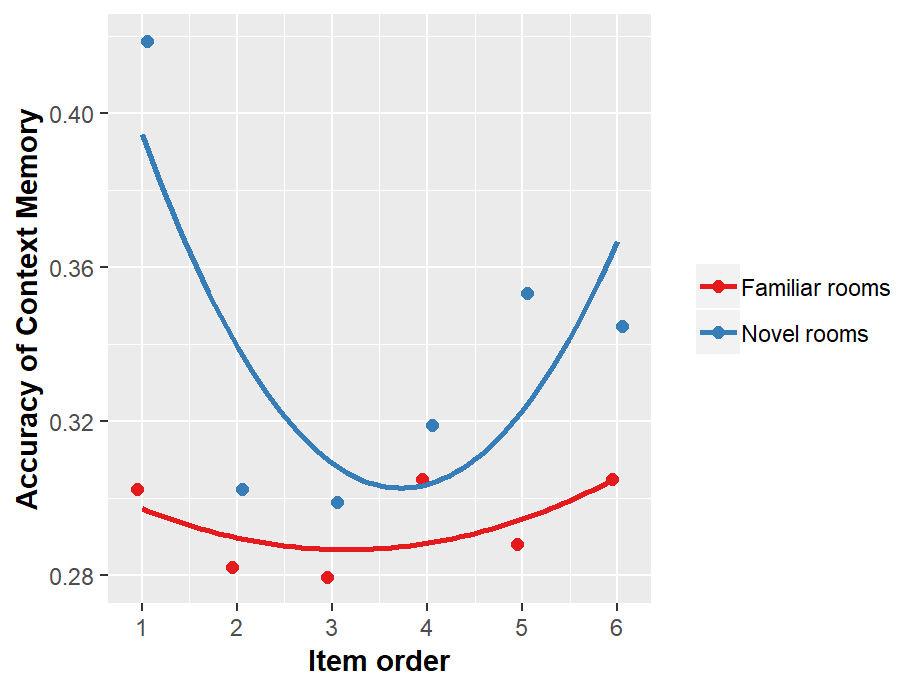

Figure 5. Mean accuracy of context memory for items at each order (i.e., 1st, 2nd, 3rd, etc), respectively for familiar and novel rooms.

### 3.1.2 Testing novelty effects by fitting mixed models

Build models with context memory accuracy as $y$ and examine effects of item order and novelty by comparing the models.

- `baseline.context` is the model with only an intercept.
- `order.model.linear.1` is the model with $\small ItemOrder$ included, showing the effects of item order.
- `order.model.linear.2` is the model allowing the slope (i.e., relationship between context memory and item order) varying across participants.
- `order.model.quad.1` and `order.model.quad.2` repectively included $\small ItemOrder^2$ and related random effects.
- `novelty.model.1` is the model with $\small Group$ (i.e., *familiar* and *novel* rooms) included, examining the effects of novelty of the rooms on the intercept (i.e., mean context memory accuracy at the 1st order or overall if no difference in slope).
- `novelty.model.2` is the model with interaction between $\small Group$ and $\small ItemOrder$ included, examining the effects of novelty on how context memory accuracy changes as a function of item order.
- `novelty.model.3` included interaction between $\small Group$ and $\small ItemOrder^2$ for inestigating whether the pattern changes between *familiar* and *novel* groups.

```
##                      Model df      AIC      BIC    logLik   Test   L.Ratio
## baseline.context         1  4 1844.134 1865.136 -918.0669
## order.model.linear.1     2  5 1846.046 1872.299 -918.0231 1 vs 2 0.0876771
## order.model.linear.2     3  9 1854.007 1901.263 -918.0034 2 vs 3 0.0393800
## order.model.quad.1       4 10 1853.796 1906.302 -916.8980 3 vs 4 2.2107781
## order.model.quad.2       5 16 1865.035 1949.045 -916.5175 4 vs 5 0.7610702
## novelty.model.1          6 14 1858.315 1931.824 -915.1577 5 vs 6 2.7195717
## novelty.model.2          7 15 1860.049 1938.808 -915.0244 6 vs 7 0.2666541
## novelty.model.3          8 16 1860.962 1944.973 -914.4812 7 vs 8 1.0863502
##                      p-value
## baseline.context
## order.model.linear.1  0.7672
## order.model.linear.2  0.9998
## order.model.quad.1    0.1370
## order.model.quad.2    0.9931
## novelty.model.1       0.2567
## novelty.model.2       0.6056
## novelty.model.3       0.2973
```

Now including none of the predictors would improve the model fit.

#### 3.1.2.1 Parameter estimation for the complete model

```
## Linear mixed-effects model fit by maximum likelihood
##  Data: Encoding.Recall.Old[!SubjectNo %in% bad.ps.less.strict]
##        AIC      BIC    logLik
##   1860.962 1944.973 -914.4812
##
## Random effects:
##  Formula: ~1 + ItemOrder + I(ItemOrder^2) | SubjectNo
##  Structure: General positive-definite, Log-Cholesky parametrization
##                StdDev     Corr
## (Intercept)    0.07575476 (Intr) ItmOrd
## ItemOrder      0.08642064 -0.950
## I(ItemOrder^2) 0.01312194  0.887 -0.978
##
##  Formula: ~1 + Group | SubjectNo %in% SubjectNo
##  Structure: General positive-definite, Log-Cholesky parametrization
##             StdDev     Corr
## (Intercept) 0.02481707 (Intr)
## GroupNovel  0.08989120 -0.925
## Residual    0.45666966
##
## Fixed effects: ContextAccuracy ~ ItemOrder + I(ItemOrder^2) + Group + ItemOrder:Group +      I(ItemOrder^2):Group
##                                 Value  Std.Error   DF   t-value p-value
## (Intercept)                0.31011634 0.07620874 1364  4.069301  0.0000
## ItemOrder                 -0.01524148 0.05109378 1364 -0.298304  0.7655
## I(ItemOrder^2)             0.00241122 0.00719520 1364  0.335115  0.7376
## GroupNovel                 0.16579076 0.10765126 1364  1.540073  0.1238
## ItemOrder:GroupNovel      -0.07874470 0.06987996 1364 -1.126857  0.2600
## I(ItemOrder^2):GroupNovel  0.01018721 0.00977687 1364  1.041971  0.2976
##  Correlation:
##                           (Intr) ItmOrd I(ItO^2) GrpNvl ItO:GN
## ItemOrder                 -0.925
## I(ItemOrder^2)             0.846 -0.979
## GroupNovel                -0.695  0.626 -0.570
## ItemOrder:GroupNovel       0.647 -0.678  0.660   -0.923
## I(ItemOrder^2):GroupNovel -0.593  0.664 -0.674    0.846 -0.979
##
## Standardized Within-Group Residuals:
##        Min         Q1        Med         Q3        Max
## -1.0307274 -0.6896902 -0.5965634  1.3315130  1.7423371
##
## Number of Observations: 1409
## Number of Groups:
##                  SubjectNo SubjectNo.1 %in% SubjectNo
##                         40                         40
```

```r
#### Parameter estimation for the optimal model
summary(order.model.quad.1, correlation = FALSE)
```

[output not shown]

### 3.1.3 Collapse the order

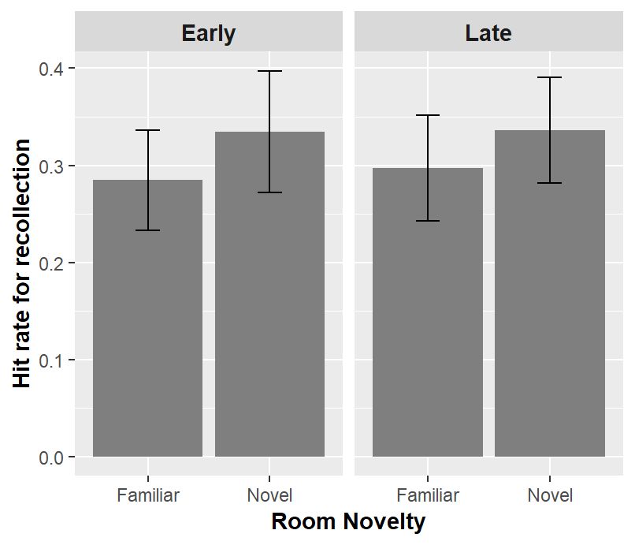

#### 3.1.3.1 Stats on it

```
## Linear mixed-effects model fit by maximum likelihood
##  Data: Encoding.Recall.Old.Collapsed.Grp
##         AIC       BIC  logLik
##   -100.4546 -75.46288 58.2273
##
## Random effects:
##  Formula: ~1 | SubjectNo
##         (Intercept)
## StdDev:  0.04716047
##
##  Formula: ~1 | Group %in% SubjectNo
##         (Intercept)
## StdDev:  0.04756967
##
##  Formula: ~1 | ItemOrderType %in% Group %in% SubjectNo
##         (Intercept)   Residual
## StdDev:   0.1529084 0.04325878
##
## Fixed effects: ContextAccuracy ~ Group * ItemOrderType
##                                    Value  Std.Error DF   t-value p-value
## (Intercept)                   0.27645503 0.02693229 82 10.264818  0.0000
## GroupNovel                    0.04768519 0.03663609 41  1.301590  0.2003
## ItemOrderTypeLate             0.01984127 0.03509728 82  0.565322  0.5734
## GroupNovel:ItemOrderTypeLate -0.01319917 0.04963505 82 -0.265924  0.7910
##  Correlation:
##                              (Intr) GrpNvl ItmOTL
## GroupNovel                   -0.680
## ItemOrderTypeLate            -0.652  0.479
## GroupNovel:ItemOrderTypeLate  0.461 -0.677 -0.707
##
## Standardized Within-Group Residuals:
##         Min          Q1         Med          Q3         Max
## -0.56772463 -0.17725203 -0.05142901  0.17864566  0.68104962
##
## Number of Observations: 168
## Number of Groups:
##                               SubjectNo
##                                      42
##                    Group %in% SubjectNo
##                                      84
## ItemOrderType %in% Group %in% SubjectNo
##                                     168
```

# 4 Curiosity Benefits

We predicted that the accuracy of context memory should increase as the curiosity rating increases.

## 4.1 Mean accuracy of context memory as a function of curiosity rating

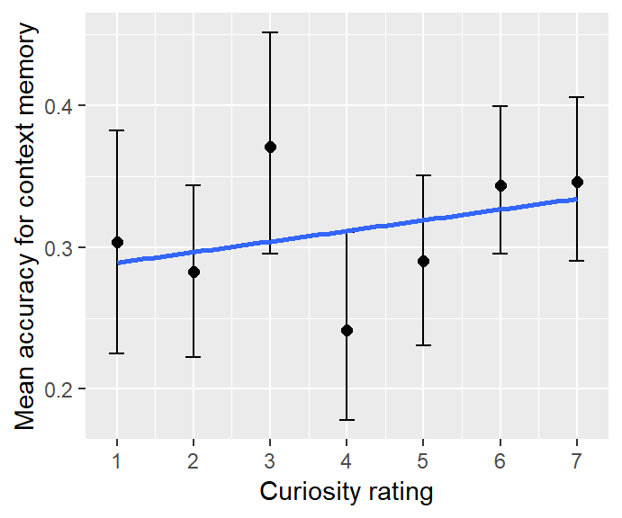

Figure 7. Mean accuracy for context memory as a function of curiosity rating.

As we predicted, the accuracy of context memory *increases* as the curiosity rating increases.

### 4.1.1 Testing the relationship between mean accuracy of context memory and curiosity rating

Build models with context memory accuracy as $y$ and examine effects of curiosity rating by including it into the model and then comparing the model fits.

- `baseline.rating` is the model with only an intercept, showing no change in context memory as a function of curiosity rating.
- `rating.intercept` is the model with $\small CuriosityRating$ included, showing the effects of curiosity rating.
- `rating.slope` is the model allowing the slope (i.e., relationship between context memory and curiosity rating) varying across participants.

```
##                  Model df        AIC       BIC   logLik   Test  L.Ratio
## baseline.rating      1  3 -100.75356 -90.36206 53.37678
## rating.intercept     2  4 -100.43340 -86.57808 54.21670 1 vs 2 1.679846
## rating.slope         3  6  -97.68123 -76.89823 54.84061 2 vs 3 1.247821
##                  p-value
## baseline.rating
## rating.intercept  0.1949
## rating.slope      0.5358
```

#### 4.1.1.1 Parameter estimates in the complete model

```r
summary(rating.slope)
```

```
## Linear mixed-effects model fit by maximum likelihood
##  Data: InsideObjectsMemory[!SubjectNo %in% bad.ps.less.strict]
##         AIC       BIC   logLik
##   -97.68123 -76.89823 54.84061
##
## Random effects:
##  Formula: ~1 + CuriosityRating | SubjectNo
##  Structure: General positive-definite, Log-Cholesky parametrization
##                 StdDev     Corr
## (Intercept)     0.12612661 (Intr)
## CuriosityRating 0.02359471 -0.869
## Residual        0.17858742
##
## Fixed effects: ContextAccuracy ~ CuriosityRating
##                      Value  Std.Error  DF  t-value p-value
## (Intercept)     0.27065447 0.03700942 195 7.313123  0.0000
## CuriosityRating 0.00955642 0.00744263 195 1.284010  0.2007
##  Correlation:
##                 (Intr)
## CuriosityRating -0.908
##
## Standardized Within-Group Residuals:
##         Min          Q1         Med          Q3         Max
## -1.94144618 -0.70306923 -0.01044649  0.74849945  3.26708474
##
## Number of Observations: 236
## Number of Groups: 40
```

The estimated value for the parameter $CuriosityRating$ is positive, as what we observed on Figure 7, but not significant. Will wait for more participants to see how this relationship changes.

#### 4.1.1.2 Plot the model

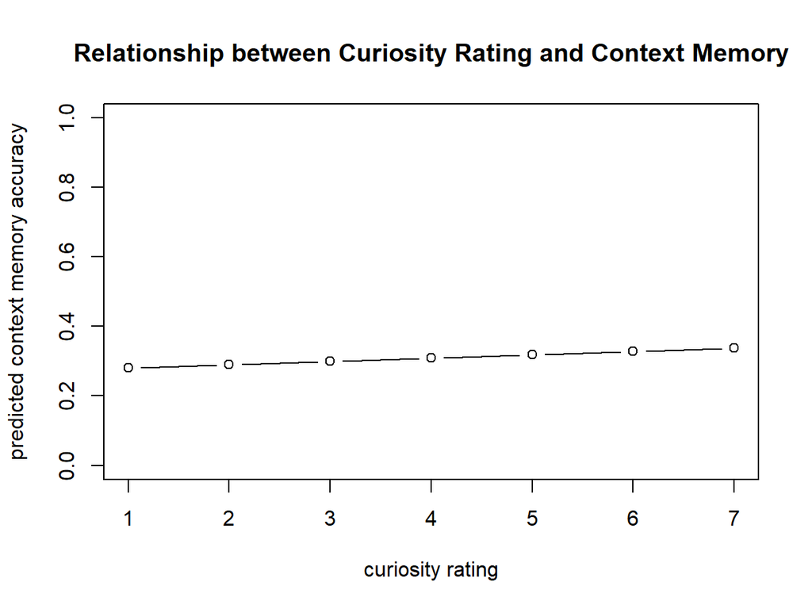

## 4.2 Does the relationship with curiosity rating depend on item order?

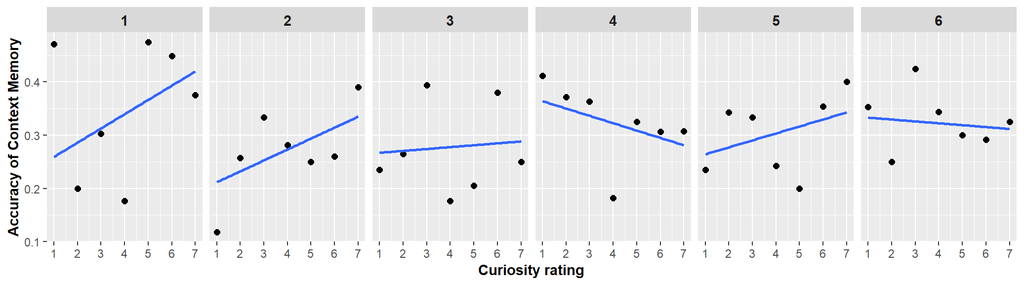

Figure 7. Mean accuracy across participants for context memory as a function of curiosity rating for each order at which the item was seen (I.e., 1st, 2nd, 3rd, etc.).

### 4.2.1 Testing the effect of item order

Build models with context memory accuracy as $y$ and examine effects of curioity rating and item order by comparing the models.

- `item.model.linear.1` is the model with $\small ItemOrder$ included (in addition to $\small CuriosityRating$), showing the effects of item order.
- `item.model.linear.2` is the model allowing the slope (i.e., relationship between context memory and item order) varying across participants.
- `item.model.linear.3` is the model with the interaction between $\small ItemOrders$ and $\small CuriosityRating$ included.
- `item.model.quad.1` and `item.model.quad.2` repectively included $\small ItemOrder^2$ and related random effects.
- `item.model.quad.3` included interaction between $\small ItemOrder^2$ and $\small CuriosityRating$ for inestigating whether the pattern changes as a function of *curiosity rating*.

```r
baseline.context <- lme(ContextAccuracy ~ 1, random = ~ 1|SubjectNo, data = Encoding.Recall.Old[! SubjectNo %in% bad.ps.less.strict], method = "ML", control = list(msMaxIter = 500, opt = "optim", msVerbose=FALSE), na.action = na.exclude)

rating.intercept <- update(baseline.context, .~. + CuriosityRating)
rating.slope     <- update(rating.intercept, random = ~ 1 + CuriosityRating | SubjectNo)

item.model.linear.1     <- update(rating.slope, .~. + ItemOrder)
item.model.linear.2     <- update(item.model.linear.1, random = list(~1+CuriosityRating + ItemOrder|SubjectNo))
item.model.linear.3     <- update(item.model.linear.2, .~. + ItemOrder : CuriosityRating)

item.model.quad.1       <- update(item.model.linear.3, .~. + I(ItemOrder^2))
# item.model.quad.2       <- update(item.model.quad.1,   random = list(~1+CuriosityRating|SubjectNo, ~1+ItemOrder+I(ItemOrder^2)|SubjectNo)) - excluding this model because singularity issue (perhaps the model was getting too complex to be calculated)
item.model.quad.3       <- update(item.model.quad.1,   .~. + I(ItemOrder^2) : CuriosityRating)

anova(rating.intercept, rating.slope, item.model.linear.1, item.model.linear.2, item.model.linear.3, item.model.quad.1, item.model.quad.3)
```

```
##                     Model df      AIC      BIC    logLik   Test   L.Ratio
## rating.intercept        1  4 1845.100 1866.102 -918.5498
## rating.slope            2  6 1848.529 1880.033 -918.2645 1 vs 2 0.5704216
## item.model.linear.1     3  7 1850.446 1887.200 -918.2230 2 vs 3 0.0830224
## item.model.linear.2     4 10 1855.346 1907.852 -917.6728 3 vs 4 1.1004531
## item.model.linear.3     5 11 1855.911 1913.668 -916.9553 4 vs 5 1.4350498
## item.model.quad.1       6 12 1855.703 1918.711 -915.8517 5 vs 6 2.2072308
## item.model.quad.3       7 13 1857.023 1925.281 -915.5113 6 vs 7 0.6808211
##                     p-value
## rating.intercept
## rating.slope         0.7519
## item.model.linear.1  0.7732
## item.model.linear.2  0.7770
## item.model.linear.3  0.2309
## item.model.quad.1    0.1374
## item.model.quad.3    0.4093
```

#### 4.2.1.1 Parameter estimation for the complete model

```r
summary(item.model.quad.3)
```

```
## Linear mixed-effects model fit by maximum likelihood
##  Data: Encoding.Recall.Old[!SubjectNo %in% bad.ps.less.strict]
##        AIC      BIC    logLik
##   1857.023 1925.281 -915.5113
##
## Random effects:
##  Formula: ~1 + CuriosityRating + ItemOrder | SubjectNo
##  Structure: General positive-definite, Log-Cholesky parametrization
##                 StdDev     Corr
## (Intercept)     0.08623227 (Intr) CrstyR
## CuriosityRating 0.02115270 -0.820
## ItemOrder       0.01416256  0.444 -0.726
## Residual        0.45913471
##
## Fixed effects: ContextAccuracy ~ CuriosityRating + ItemOrder + I(ItemOrder^2) +      CuriosityRating:ItemOrder + CuriosityRating:I(ItemOrder^2)
##                                      Value  Std.Error   DF    t-value
## (Intercept)                     0.19108233 0.13700599 1364  1.3947005
## CuriosityRating                 0.04484852 0.02845299 1364  1.5762325
## ItemOrder                       0.03289857 0.08914865 1364  0.3690304
## I(ItemOrder^2)                 -0.00212962 0.01245673 1364 -0.1709611
## CuriosityRating:ItemOrder      -0.01938819 0.01846981 1364 -1.0497237
## CuriosityRating:I(ItemOrder^2)  0.00212314 0.00258161 1364  0.8224094
##                                p-value
## (Intercept)                     0.1633
## CuriosityRating                 0.1152
## ItemOrder                       0.7122
## I(ItemOrder^2)                  0.8643
## CuriosityRating:ItemOrder       0.2940
## CuriosityRating:I(ItemOrder^2)  0.4110
##  Correlation:
##                                (Intr) CrstyR ItmOrd I(IO^2 CrR:IO
## CuriosityRating                -0.918
## ItemOrder                      -0.924  0.847
## I(ItemOrder^2)                  0.849 -0.778 -0.979
## CuriosityRating:ItemOrder       0.851 -0.924 -0.919  0.899
## CuriosityRating:I(ItemOrder^2) -0.780  0.847  0.899 -0.919 -0.979
##
## Standardized Within-Group Residuals:
##        Min         Q1        Med         Q3        Max
## -1.0772489 -0.6958269 -0.6108319  1.3718409  1.6803625
##
## Number of Observations: 1409
## Number of Groups: 40
```

Maybe because of being lack of power (too many parameters and too few participants), no parameter has a significant estimated value.

```r
#### Parameter estimation for the optimal model
summary(item.model.quad.1)
```

[output not shown]

### 4.2.2 Collapse the order and curiosity rating

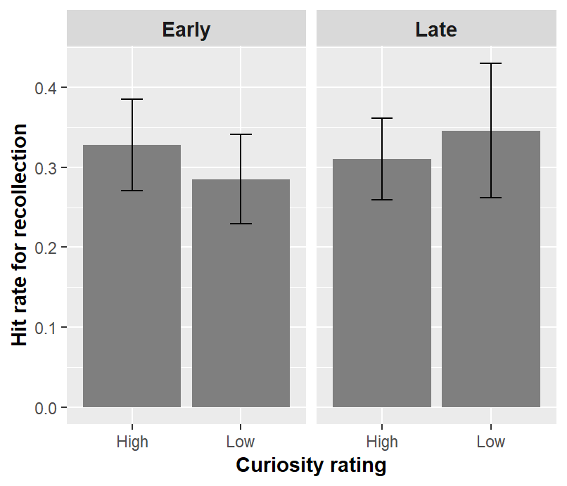

Figure 7. Mean hit rate as a function of item order (Early vs. Late) and curiosity (Low vs. High).

#### 4.2.2.1 Stats on it

```
## Linear mixed-effects model fit by maximum likelihood
##  Data: Encoding.Recall.Old.Collapsed
##         AIC       BIC   logLik
##   -64.01815 -39.41676 40.00908
##
## Random effects:
##  Formula: ~1 | SubjectNo
##         (Intercept)
## StdDev:   0.0433152
##
##  Formula: ~1 | CuriosityRatingType %in% SubjectNo
##         (Intercept)
## StdDev:  0.09449619
##
##  Formula: ~1 | ItemOrderType %in% CuriosityRatingType %in% SubjectNo
##         (Intercept)   Residual
## StdDev:   0.1546107 0.04955159
##
## Fixed effects: ContextAccuracy ~ CuriosityRatingType * ItemOrderType
##                                               Value  Std.Error DF
## (Intercept)                               0.3280724 0.03012614 78
## CuriosityRatingTypeLow                   -0.0433170 0.04264613 37
## ItemOrderTypeLate                        -0.0180573 0.03588058 78
## CuriosityRatingTypeLow:ItemOrderTypeLate  0.0786880 0.05206101 78
##                                            t-value p-value
## (Intercept)                              10.889958  0.0000
## CuriosityRatingTypeLow                   -1.015732  0.3164
## ItemOrderTypeLate                        -0.503260  0.6162
## CuriosityRatingTypeLow:ItemOrderTypeLate  1.511458  0.1347
##  Correlation:
##                                          (Intr) CrsRTL ItmOTL
## CuriosityRatingTypeLow                   -0.671
## ItemOrderTypeLate                        -0.596  0.421
## CuriosityRatingTypeLow:ItemOrderTypeLate  0.410 -0.610 -0.689
##
## Standardized Within-Group Residuals:
##         Min          Q1         Med          Q3         Max
## -0.59911785 -0.18933150 -0.04622765  0.18784081  0.94741920
##
## Number of Observations: 160
## Number of Groups:
##                                             SubjectNo
##                                                    42
##                    CuriosityRatingType %in% SubjectNo
##                                                    80
## ItemOrderType %in% CuriosityRatingType %in% SubjectNo
##                                                   160
```

### 4.2.3 Try another way to calculate “High” and “Low” curiosity groups

> “High” - higher than mean; “Low” - lower than mean

#### 4.2.3.1 Compare “High” and “Low” groups

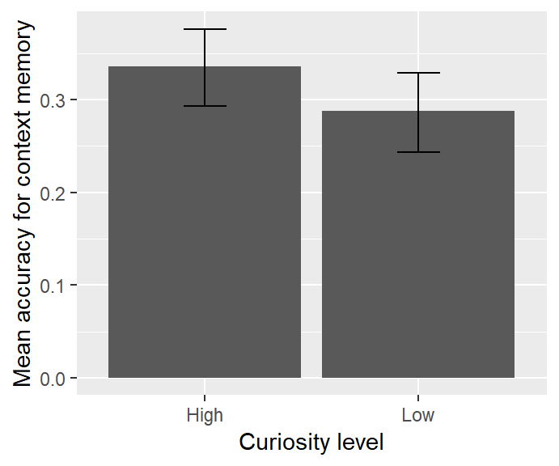

```
##
##  Paired t-test
##
## data:  ContextAccuracy by RatingGroup
## t = 1.6931, df = 39, p-value = 0.09841
## alternative hypothesis: true difference in means is not equal to 0
## 95 percent confidence interval:
##  -0.009381231  0.105770120
## sample estimates:
## mean of the differences
##              0.04819444
```

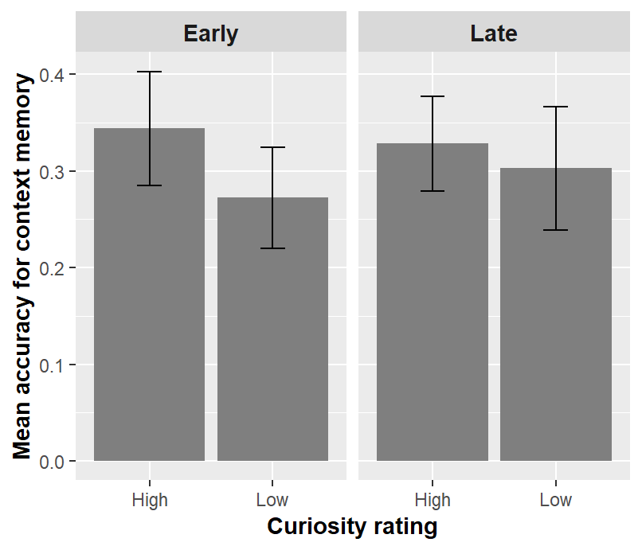

#### 4.2.3.2 Stats on it

```
## Linear mixed-effects model fit by maximum likelihood
##  Data: Encoding.Recall.Old.Collapsed.Alt[!SubjectNo %in% bad.ps.less.strict]
##         AIC       BIC   logLik
##   -92.73464 -68.13325 54.36732
##
## Random effects:
##  Formula: ~1 | SubjectNo
##         (Intercept)
## StdDev:  0.04360292
##
##  Formula: ~1 | RatingGroup %in% SubjectNo
##         (Intercept)
## StdDev:  0.05651462
##
##  Formula: ~1 | ItemOrderType %in% RatingGroup %in% SubjectNo
##         (Intercept)   Residual
## StdDev:    0.152129 0.04422498
##
## Fixed effects: ContextAccuracy ~ RatingGroup * ItemOrderType
##                                       Value  Std.Error DF   t-value
## (Intercept)                       0.3437816 0.02782464 78 12.355293
## RatingGroupLow                   -0.0715593 0.03809098 39 -1.878643
## ItemOrderTypeLate                -0.0156268 0.03587664 78 -0.435570
## RatingGroupLow:ItemOrderTypeLate  0.0461824 0.05073723 78  0.910226
##                                  p-value
## (Intercept)                       0.0000
## RatingGroupLow                    0.0678
## ItemOrderTypeLate                 0.6644
## RatingGroupLow:ItemOrderTypeLate  0.3655
##  Correlation:
##                                  (Intr) RtngGL ItmOTL
## RatingGroupLow                   -0.684
## ItemOrderTypeLate                -0.645  0.471
## RatingGroupLow:ItemOrderTypeLate  0.456 -0.666 -0.707
##
## Standardized Within-Group Residuals:
##         Min          Q1         Med          Q3         Max
## -0.57558358 -0.17450718 -0.03563401  0.18666178  0.65754172
##
## Number of Observations: 160
## Number of Groups:
##                                     SubjectNo
##                                            40
##                    RatingGroup %in% SubjectNo
##                                            80
## ItemOrderType %in% RatingGroup %in% SubjectNo
##                                           160
```

##### 4.2.3.2.1 Simple effects in “Early”

```r
t.test(ContextAccuracy ~ RatingGroup, data = Encoding.Recall.Old.Collapsed.Alt[!SubjectNo %in% c(bad.ps.less.strict) & ItemOrderType == "Early"], paired = T)
```

```
##
##  Paired t-test
##
## data:  ContextAccuracy by RatingGroup
## t = 1.7381, df = 39, p-value = 0.09009
## alternative hypothesis: true difference in means is not equal to 0
## 95 percent confidence interval:
##  -0.01171889  0.15483758
## sample estimates:
## mean of the differences
##              0.07155934
```

# 5 Curiosity and novelty

## 5.1 Testing the effects of curiosity rating and novelty together

Build models with context memory accuracy as $y$ and examine effects of curiosity rating and novelty together by including them into the model separately and then comparing the model fits.

```
##                   Model df       AIC       BIC   logLik   Test   L.Ratio
## baseline.rating       1  4 -113.1188 -99.06512 60.55942
## rating.intercept      2  5 -112.2472 -94.68007 61.12361 1 vs 2 1.1283778
## rating.slope          3  9 -104.9510 -73.33011 61.47548 2 vs 3 0.7037558
## novelty.model         4 10 -103.8336 -68.69929 61.91679 3 vs 4 0.8826109
## interaction.model     5 11 -103.8910 -65.24326 62.94549 4 vs 5 2.0573913
##                   p-value
## baseline.rating
## rating.intercept   0.2881
## rating.slope       0.9509
## novelty.model      0.3475
## interaction.model  0.1515
```

### 5.1.1 Check the complete model

```
## Linear mixed-effects model fit by maximum likelihood
##  Data: InsideObjectsMemory
##        AIC       BIC   logLik
##   -103.891 -65.24326 62.94549
##
## Random effects:
##  Formula: ~1 + CuriosityRating | SubjectNo
##  Structure: General positive-definite, Log-Cholesky parametrization
##                 StdDev     Corr
## (Intercept)     0.10484061 (Intr)
## CuriosityRating 0.01360989 -0.959
##
##  Formula: ~1 + CuriosityRating | Group %in% SubjectNo
##  Structure: General positive-definite, Log-Cholesky parametrization
##                 StdDev       Corr
## (Intercept)     0.0002583336 (Intr)
## CuriosityRating 0.0139168468 0.075
## Residual        0.1703912465
##
## Fixed effects: ContextAccuracy ~ CuriosityRating + Group + CuriosityRating:Group
##                                 Value  Std.Error  DF   t-value p-value
## (Intercept)                 0.3192106 0.04339946 162  7.355174  0.0000
## CuriosityRating            -0.0107110 0.01274079 162 -0.840686  0.4018
## GroupNovel                 -0.1037093 0.10457987  41 -0.991676  0.3272
## CuriosityRating:GroupNovel  0.0298585 0.02071484 162  1.441406  0.1514
##  Correlation:
##                            (Intr) CrstyR GrpNvl
## CuriosityRating            -0.888
## GroupNovel                 -0.351  0.337
## CuriosityRating:GroupNovel  0.505 -0.593 -0.929
##
## Standardized Within-Group Residuals:
##        Min         Q1        Med         Q3        Max
## -1.9764599 -0.6437901 -0.0261347  0.6025450  3.1448422
##
## Number of Observations: 248
## Number of Groups:
##            SubjectNo Group %in% SubjectNo
##                   42                   84
```

## 5.2 What about the other way around

```
##                   Model df      AIC      BIC    logLik   Test  L.Ratio
## baseline.context      1  3 1844.757 1860.509 -919.3788
## novelty.model         2  4 1843.375 1864.377 -917.6873 1 vs 2 3.382852
## rating.model.1        3  5 1845.321 1871.574 -917.6603 2 vs 3 0.054015
## rating.model.2        4 10 1853.617 1906.123 -916.8083 3 vs 4 1.703966
## interaction.model     5 11 1854.447 1912.204 -916.2236 4 vs 5 1.169393
##                   p-value
## baseline.context
## novelty.model      0.0659
## rating.model.1     0.8162
## rating.model.2     0.8884
## interaction.model  0.2795
```

## 5.3 Check the collapsed data

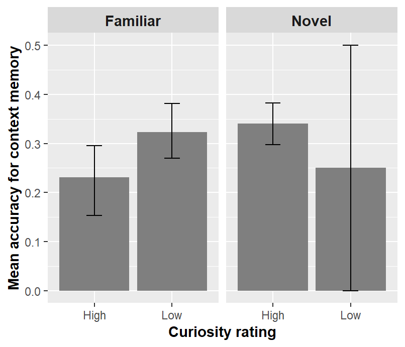

#### 5.3.0.1 Stats on it

```
## Linear mixed-effects model fit by maximum likelihood
##  Data: Encoding.Recall.Old.Collapsed.Interaction[!SubjectNo %in% bad.ps.less.strict]
##         AIC       BIC   logLik
##   -65.08875 -45.00188 40.54438
##
## Random effects:
##  Formula: ~1 | SubjectNo
##         (Intercept)
## StdDev: 0.001038032
##
##  Formula: ~1 | CuriosityRatingType %in% SubjectNo
##         (Intercept)
## StdDev:  0.07192918
##
##  Formula: ~1 | Group %in% CuriosityRatingType %in% SubjectNo
##         (Intercept)   Residual
## StdDev:    0.137509 0.01095886
##
## Fixed effects: ContextAccuracy ~ CuriosityRatingType * Group
##                                         Value  Std.Error DF   t-value
## (Intercept)                        0.22780478 0.04344346 39  5.243706
## CuriosityRatingTypeLow             0.09549756 0.05089720 35  1.876283
## GroupNovel                         0.11302856 0.04743002 13  2.383059
## CuriosityRatingTypeLow:GroupNovel -0.17066625 0.12150688 13 -1.404581
##                                   p-value
## (Intercept)                        0.0000
## CuriosityRatingTypeLow             0.0690
## GroupNovel                         0.0331
## CuriosityRatingTypeLow:GroupNovel  0.1836
##  Correlation:
##                                   (Intr) CrsRTL GrpNvl
## CuriosityRatingTypeLow            -0.854
## GroupNovel                        -0.850  0.726
## CuriosityRatingTypeLow:GroupNovel  0.332 -0.373 -0.390
##
## Standardized Within-Group Residuals:
##          Min           Q1          Med           Q3          Max
## -0.146384307 -0.051889650  0.004538591  0.048870547  0.230931962
##
## Number of Observations: 91
## Number of Groups:
##                                     SubjectNo
##                                            40
##            CuriosityRatingType %in% SubjectNo
##                                            76
## Group %in% CuriosityRatingType %in% SubjectNo
##                                            91
```

### 5.3.1 Alternative way to collapse data

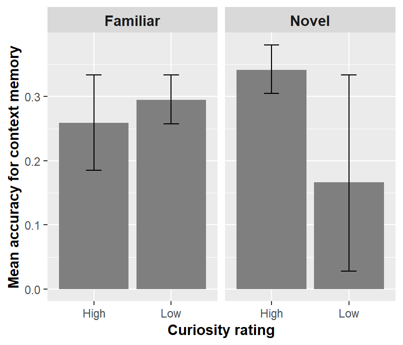

```
## Linear mixed-effects model fit by maximum likelihood
##  Data: Encoding.Recall.Old.Collapsed.Alt.Interaction[!SubjectNo %in%      bad.ps.less.strict]
##         AIC       BIC   logLik
##   -94.97657 -74.54556 55.48829
##
## Random effects:
##  Formula: ~1 | SubjectNo
##         (Intercept)
## StdDev:   0.0284366
##
##  Formula: ~1 | RatingGroup %in% SubjectNo
##         (Intercept)
## StdDev:  0.06212536
##
##  Formula: ~1 | Group %in% RatingGroup %in% SubjectNo
##         (Intercept) Residual
## StdDev:   0.1137687 0.028366
##
## Fixed effects: ContextAccuracy ~ RatingGroup * Group
##                                 Value  Std.Error DF   t-value p-value
## (Intercept)                0.25956106 0.04503360 39  5.763720  0.0000
## RatingGroupLow             0.03557783 0.04966343 39  0.716379  0.4780
## GroupNovel                 0.08196672 0.04759198 13  1.722280  0.1087
## RatingGroupLow:GroupNovel -0.20873672 0.07489190 13 -2.787174  0.0154
##  Correlation:
##                           (Intr) RtngGL GrpNvl
## RatingGroupLow            -0.897
## GroupNovel                -0.889  0.806
## RatingGroupLow:GroupNovel  0.577 -0.620 -0.647
##
## Standardized Within-Group Residuals:
##         Min          Q1         Med          Q3         Max
## -0.45654152 -0.18656162 -0.01146967  0.15638387  0.56638803
##
## Number of Observations: 95
## Number of Groups:
##                             SubjectNo
##                                    40
##            RatingGroup %in% SubjectNo
##                                    80
## Group %in% RatingGroup %in% SubjectNo
##                                    95
```

# 6 Curiosity effects in the *Novel* group

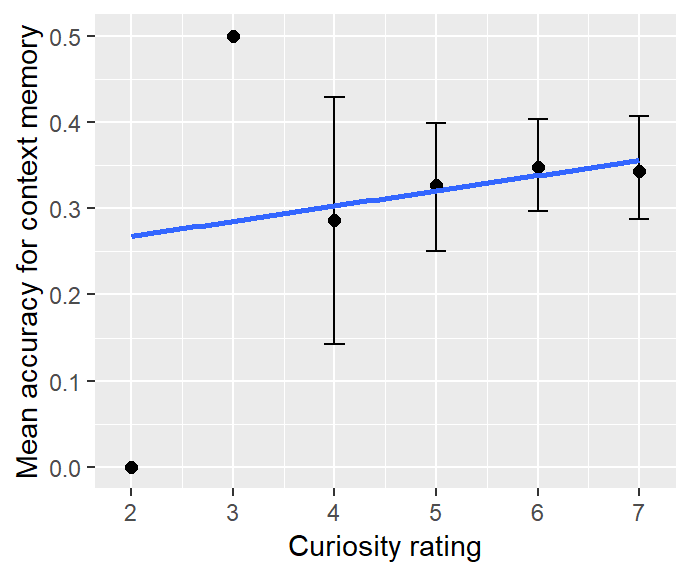